# Unit 1 Final Assignment

Yifan Liu

2020/10/13

# Exploratory data analysis into the chemicals being applied to strawberries

## Acquire and read the data

These data were collected from the National Agricultural Statistics Service, which is the statistical branch of the U.S. Department of Agriculture. According to its website, NASS conducts hundreds of surveys and issues nearly 500 national reports each year on issues like agricultural production, economics, demographics, and the environment. The data were collected from the USDA database selector: https://quickstats.nass.usda.gov which were mainly about the information about berries.

The data were [stored online](https://quickstats.nass.usda.gov/results/D416E96E-3D5C-324C-9334-1D38DF88FFF1) and then downloaded as a CSV file.

The berries data only had 8 out of 21 columns containing meaningful data. Thus further data cleaning methods are required. Below is a preview of the first parts of the original data.

Year

Period

State

Commodity

Data Item

Domain

Domain Category

Value

2019

MARKETING YEAR

CALIFORNIA

BLUEBERRIES

BLUEBERRIES, TAME - PRICE RECEIVED, MEASURED IN $ / LB

TOTAL

NOT SPECIFIED

2.85

2019

MARKETING YEAR

CALIFORNIA

BLUEBERRIES

BLUEBERRIES, TAME, FRESH MARKET - PRICE RECEIVED, MEASURED IN $ / LB

TOTAL

NOT SPECIFIED

3.56

2019

MARKETING YEAR

CALIFORNIA

BLUEBERRIES

BLUEBERRIES, TAME, PROCESSING - PRICE RECEIVED, MEASURED IN $ / LB

TOTAL

NOT SPECIFIED

0.29

2019

MARKETING YEAR

CALIFORNIA

RASPBERRIES

RASPBERRIES - PRICE RECEIVED, MEASURED IN $ / LB

TOTAL

NOT SPECIFIED

2.69

2019

MARKETING YEAR

CALIFORNIA

RASPBERRIES

RASPBERRIES, FRESH MARKET - PRICE RECEIVED, MEASURED IN $ / LB

TOTAL

NOT SPECIFIED

2019

MARKETING YEAR

CALIFORNIA

RASPBERRIES

RASPBERRIES, PROCESSING - PRICE RECEIVED, MEASURED IN $ / LB

TOTAL

NOT SPECIFIED

After examining the commodities in the dataset, there are three types of berries: blueberries, raspberries, and strawberries. In this analysis, only the strawberries are focused and only the `Year` time period will be considered.

## Data Cleaning and Organization

### Method

- First filter out a dataset names `sberry` which contains all the strawberries data from the original dataset. Then separate the `Data Item` column into several different columns so that further cleaning process can be conducted.
- Similarly, separate the `Domain` and the `Domain Category` columns for further cleaning process.
- The next step is to find and remove the redundant columns.
- Then the `what` and the `means` columns need to be cleaned and re-organized. The objective is to put these two columns all in the same column. In order to do so, separation is needed first and then test to make sure there are no overlaps.
- Finally rename the columns of the dataset and select those that are required in this analysis.

### Preview of the data

Below are the column names of the cleaned dataset for straw berries.

```
## [1] "Year"       "State"      "type"       "production" "Avg"        "Measures"   "Materials"  "Chemical"   "Value"
```

Below is the preview of the cleaned dataset for straw berries.

| Year | State | type | production | Avg | Measures | Materials | Chemical | Value |
| --- | --- | --- | --- | --- | --- | --- | --- | --- |
| 2019 | CALIFORNIA |  |  |  |  |  |  | 35,400 |
| 2019 | CALIFORNIA |  |  |  |  |  |  | 36,000 |
| 2019 | CALIFORNIA | MEASURED | $ |  |  |  |  | 2,221,320,000 |
| 2019 | CALIFORNIA | MEASURED | CWT |  |  |  |  | 20,500,000 |
| 2019 | CALIFORNIA | MEASURED | CWT / |  |  |  |  | 580 |
| 2019 | CALIFORNIA | BEARING | APPLICATIONS |  | MEASURED IN LB | (AZOXYSTROBIN = 128810) | FUNGICIDE | 5,500 |
| 2019 | CALIFORNIA | BEARING | APPLICATIONS |  | MEASURED IN LB | (BACILLUS AMYLOLIQUEFACIENS MBI 600 = 129082) | FUNGICIDE | (NA) |
| 2019 | CALIFORNIA | BEARING | APPLICATIONS |  | MEASURED IN LB | (BACILLUS AMYLOLIQUEFACIENS STRAIN D747 = 16482) | FUNGICIDE | (NA) |
| 2019 | CALIFORNIA | BEARING | APPLICATIONS |  | MEASURED IN LB | (BACILLUS PUMILUS = 6485) | FUNGICIDE | (NA) |
| 2019 | CALIFORNIA | BEARING | APPLICATIONS |  | MEASURED IN LB | (BACILLUS SUBT. GB03 = 129068) | FUNGICIDE | (NA) |

## Visualizations

Suppose we want to explore the chemicals being applied to strawberries. First we need to filter out the related dataset named `unfood_1`.

Below is a basic summary of the data.

```
##       Year         State             Chemical             Value
##  Min.   :2016   Length:225         Length:225         Min.   :  0.01000
##  1st Qu.:2016   Class :character   Class :character   1st Qu.:  0.09775
##  Median :2018   Mode  :character   Mode  :character   Median :  0.21350
##  Mean   :2018                                         Mean   :  7.36077
##  3rd Qu.:2019                                         3rd Qu.:  0.66150
##  Max.   :2019                                         Max.   :251.55900
##                                                       NA's   :1
```

We first create a box plot of chemical values being applied to strawberries according to state.

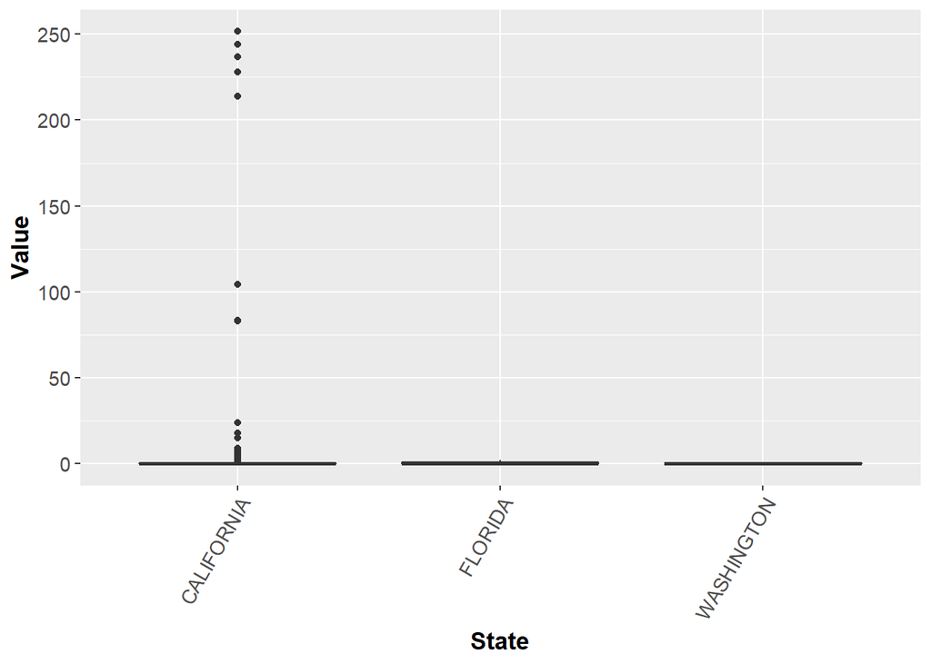

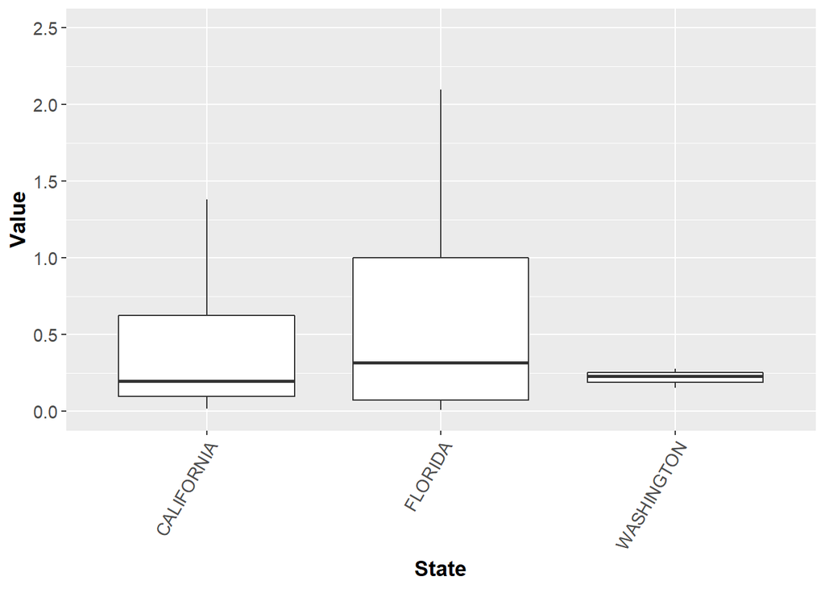

We can repeat the same procedure to visualize the distributions of chemicals being applied to strawberries according to different types of chemical.

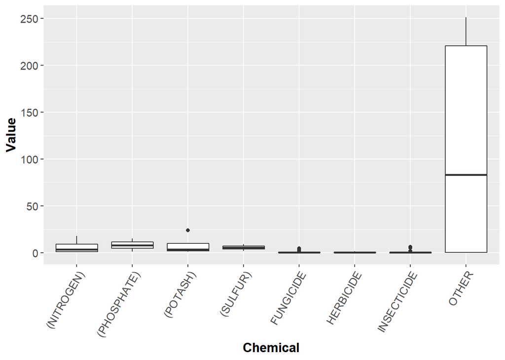

According to the box plot we can discover that there appears to have two different groups of chemicals with extremely different ranges of values. Thus we can divide our `unfood_1` dataset into two sets according to two different groups of chemicals and then plot.

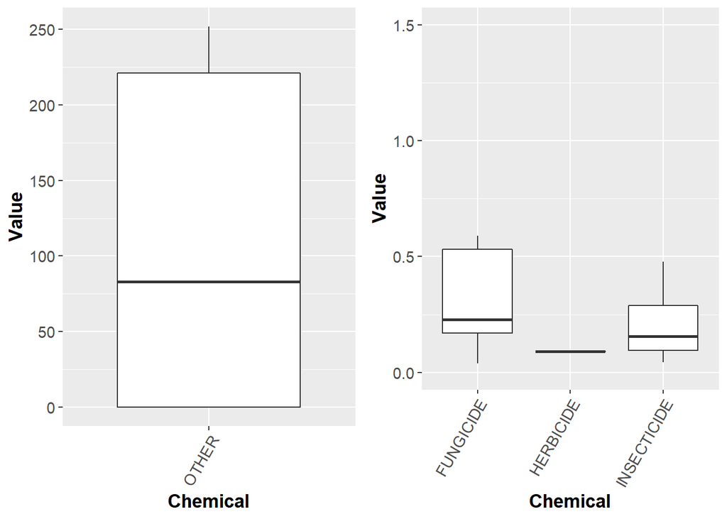

Then we can create a histogram to see the least and most variance chemicals. According to the histogram, we can see that over 150 out of 225 brands of strawberries have values of chemicals below 0.5. However, there is still a wide distribution of the values of chemicals contained by selected strawberries due to the varieties of chemicals which require further analysis.

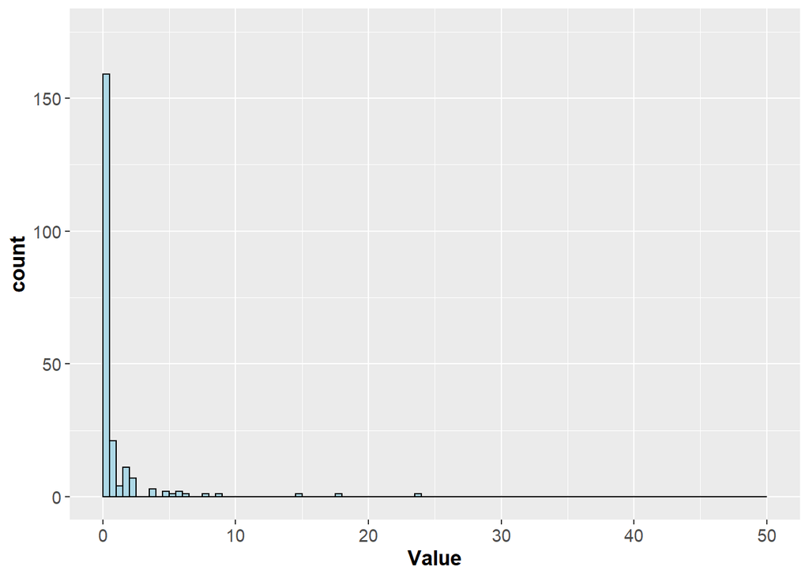

## Conclusion

After the basic exploratory data analysis, we could come out with these conclusions:

## Citation

- David Morison (2017) Exploratory data analysis into the relationship between different types of crime in London. Available at: https://towardsdatascience.com/exploratory-data-analysis-into-the-relationship-between-different-types-of-crime-in-london-20c328e193ff (Accessed: 15 Oct 2020).
- United States Department of Agriculture National Agricultural Statistics Service (n.p.) Quick Stats. Available at: https://quickstats.nass.usda.gov/results/D416E96E-3D5C-324C-9334-1D38DF88FFF1 (Accessed: 15 Oct 2020).

[output not shown]

[output cut: 240 more lines]

[output not shown]

[output not shown]

[output not shown]

[output not shown]